# N addition amplify drought sensitivity

Author

Liang

## 1 load packages

```r
library(tidyverse)
library(bigleaf)
library(minpack.lm)
library(ggprism)
library(latex2exp)
library(ggpubr)
```

## 2 Calculation of physiological parameters

### 2.1 ROS2 site (whole period)

In this part, we would like to calculate the half-hourly canopy conductance (Gc) for whole period.

```r
# with HH time scale
ros2 <- read.csv("ros2_full_gapfilled.csv")
ros2$VPD_f <- ros2$VPD_f /10.0 # to kPa
ros2$pressure_f <- ros2$pressure_f /10.0 # to kpa
# Some Constant LAI
LAI = 2.5 # LEAF AREA INDEX
zh = 18.4 # PLANT HEIGHT
zr = 23 # SENSOR HEIGHT
DL = NULL # LEAF LENGTH
```

```r
Gc <- aerodynamic.conductance(ros2,
                        Tair = "Tair_f",
                        pressure = "pressure_f",
                        wind = "WS_f",
                        ustar = "Ustar_f",
                        H = "H_f",
                        zr = zr,
                        zh = zh,
                        LAI = LAI,
                        Rb_model = "Thom_1972")
```

```
Note new column 'z0h' in the function output for 'bigleaf' versions > 0.7.5.
```

```r
# add Ga column to ROS2
ros2$Ga_h <- Gc$Ga_h
# calculate canopy conductance

Gs <- surface.conductance(ros2,
                          Tair = "Tair_f",
                          pressure = "pressure_f",
                          Rn = "Rn_f",
                          G="G_f",
                          VPD = "VPD_f",
                          LE = "LE_f",
                          Ga = "Ga_h",
                          formulation="Penman-Monteith")
```

```
Energy storage fluxes S are not provided and set to 0.
```

```r
# stomata
ros2$Gs_mol <- Gs$Gs_mol
ros2$Gs_ms <- Gs$Gs_ms
```

The following is for daily conversion, here we only keep day time (PPFD > 200)

```r
ros2 %>%
    filter(Gs_mol < 1 & Gs_mol >=0) %>%
    transmute(Gs_mol = Gs_mol,
              VPD_f = VPD_f,
              PPFD_f = PPFD_f,
              year = year(dt),
              month = month(dt),day = day(dt)) %>%
    unique.data.frame() -> ros2_dd

ros2_dd %>%
    filter(month %in% c(6,7,8)  & PPFD_f > 200) -> ros2_dd
```

Then we could calculate the m — stomata sensitivity to VPD

```r
# creat bin group for vpd and Gs
bins_group <- findInterval(ros2_dd$VPD_f,
                           seq(from=0.6,to = 3.0,by = 0.2))
ros2_dd$id <- bins_group

Gc_std <- sd(ros2_dd$Gs_mol)

#taking different stratages
## get mean value
## applied the upper envolop line of VPD and GS
ros2_dd %>%
    group_by(id) %>%
    transmute(Gs_mol = mean(Gs_mol) + Gc_std) %>%
    unique.data.frame() -> ros2_dd

ros2_dd$vpd <- seq(from=0.6,to = 3.2,by = 0.2)

# simulate the GS sensitivity
mod <- nlsLM(Gs_mol ~ -m * log(vpd) + b,
             data = ros2_dd,
             start=list(m=10,b=2),
             algorithm = "plinear",
             na.action = na.omit)
summary(mod)
```

```
Formula: Gs_mol ~ -m * log(vpd) + b

Parameters:
  Estimate Std. Error t value Pr(>|t|)
m 0.165404   0.010071   16.42 1.37e-09 ***
b 0.422404   0.007334   57.59 4.96e-16 ***
---
Signif. codes:  0 '***' 0.001 '**' 0.01 '*' 0.05 '.' 0.1 ' ' 1

Residual standard error: 0.01874 on 12 degrees of freedom

Number of iterations to convergence: 2
Achieved convergence tolerance: 1.49e-08
```

```r
#
```

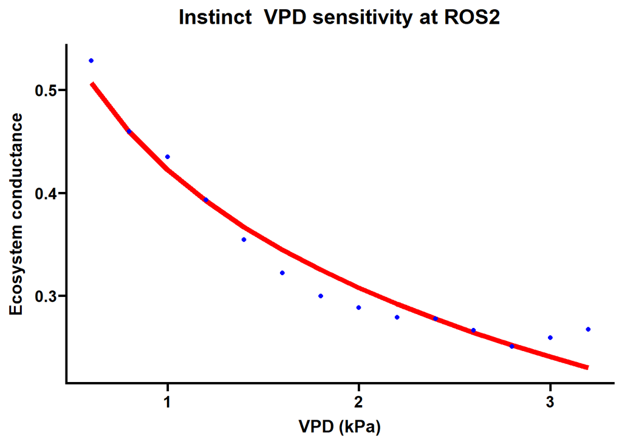

```r
ros2_dd %>%
    ggplot() +
    geom_line(aes(x = ros2_dd$vpd,
                  y= -0.165404 * log(ros2_dd$vpd) + 0.422404),
              color = "red",size = 2)+
    geom_point(aes(x = ros2_dd$vpd,
                  y= Gs_mol),
              color = "blue")+
    ggtitle("Instinct  VPD sensitivity at ROS2")+
    xlab("VPD (kPa)")+
    ylab("Ecosystem conductance")+
    theme_prism()
```

Here, it should be also noticed that, we aggregate all data from Jun. to Aug. not only the dry days, which is, $P_{anomaly}$ < 0. We could further calculate the m during dry day as well.

### 2.2 ROS3 site (whole period)

Similar to above processes, we applied all steps to ROS3 site (the Control site).

```r
ros3<- read.csv("ros3_full_gapfilled.csv")
ros3$VPD_f <- ros3$VPD_f /10.0 # to kPa
ros3$pressure_f <- ros3$pressure_f /10.0 # to kpa
# Some Constant LAI at ROS3
LAI = 2.5 # LEAF AREA INDEX
zh = 19.1 # PLANT HEIGHT
zr = 23.5 # SENSOR HEIGHT
DL = NULL # LEAF LENGTH


#
Gc <- aerodynamic.conductance(ros3,
                              Tair = "Tair_f",
                              pressure = "pressure_f",
                              wind = "WS_f",
                              ustar = "Ustar_f",
                              H = "H_f",
                              zr = zr,
                              zh = zh,
                              LAI = LAI,
                              Rb_model = "Thom_1972"
)
```

```
Note new column 'z0h' in the function output for 'bigleaf' versions > 0.7.5.
```

```r
# add Ga column to ros3
ros3$Ga_h <- Gc$Ga_h
# calculate canopy conductance

Gs <- surface.conductance(ros3,
                          Tair = "Tair_f",
                          pressure = "pressure_f",
                          Rn = "Rn_f",
                          G="G_f",
                          VPD = "VPD_f",
                          LE = "LE_f",
                          Ga = "Ga_h",
                          formulation="Penman-Monteith",

)
```

```
Energy storage fluxes S are not provided and set to 0.
```

```r
ros3$Gs_mol <- Gs$Gs_mol

ros3$Gs_ms <- Gs$Gs_ms
```

```r
# TO daily scale
# only keep daytime data
ros3 %>%
    filter(Gs_mol < 1 & Gs_mol >=0) %>%
    transmute(Gs_mol = Gs_mol,
              VPD_f = VPD_f,
              PPFD_f = PPFD_f,
              year = year(dt),month = month(dt),day = day(dt)) %>%
    unique.data.frame() -> ros3_dd

ros3_dd %>%
    filter(month %in% c(6,7,8) & PPFD_f > 200) -> ros3_dd
```

```r
# creat bin group for vpd and Gs
bins_group <- findInterval(ros3_dd$VPD_f , seq(from=0.6,to = 3.0,by = 0.2))
ros3_dd$id <- bins_group

Gc3_std <- sd(ros3_dd$Gs_mol)

#taking different stratages
## get mean value
ros3_dd %>%
    group_by(id) %>%
    transmute(Gs_mol = mean(Gs_mol)+ Gc3_std) %>%
    unique.data.frame() -> ros3_dd

ros3_dd$vpd <- seq(from=0.6,to = 3.2,by = 0.2)
```

```r
# simulate the GS sensitivity
mod1 <- nlsLM(Gs_mol ~ -m * log(vpd) + b,
             data = ros3_dd,
             start=list(m=10,b=2),
             algorithm = "plinear",
             # alg = "plinear",
             na.action = na.omit)
summary(mod1)
```

```
Formula: Gs_mol ~ -m * log(vpd) + b

Parameters:
  Estimate Std. Error t value Pr(>|t|)
m 0.157740   0.007248   21.76 5.19e-11 ***
b 0.380785   0.005279   72.14  < 2e-16 ***
---
Signif. codes:  0 '***' 0.001 '**' 0.01 '*' 0.05 '.' 0.1 ' ' 1

Residual standard error: 0.01349 on 12 degrees of freedom

Number of iterations to convergence: 2
Achieved convergence tolerance: 1.49e-08
```

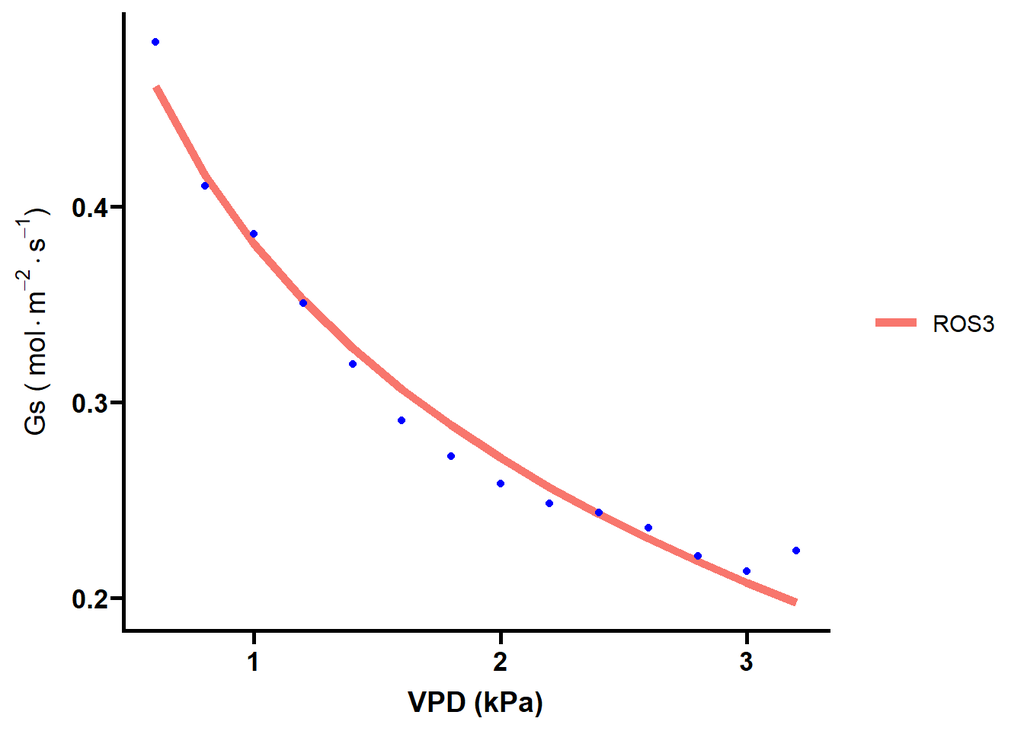

```r
ros3_dd %>%
    ggplot() +
   # geom_line(aes(x = ros2_dd$vpd,
    #              y= -0.165404 * log(ros2_dd$vpd) + 0.422404-0.5068966,
    #              color = "ROS2"),
     #         size = 2)+
    geom_line(aes(x = ros3_dd$vpd,
                  y= -0.157740  * log(ros3_dd$vpd) + 0.380785,
                  color = "ROS3"),
              size = 2)+
     geom_point(aes(x = ros3_dd$vpd,
                  y= Gs_mol),
              color = "blue")+
    #ggtitle("Instinct  VPD sensitivity at ROS2 & ROS3")+
    xlab("VPD (kPa)")+
    ylab(TeX("Gs ( $mol \\cdot m^{-2} \\cdot s^{-1}$)"))+
    theme_prism()
```

If we combine the two lines, we can clearly see that ROS2 is more sensitive to Gc to VPD during summerthan ROS3. We would like to compare again during dry days.

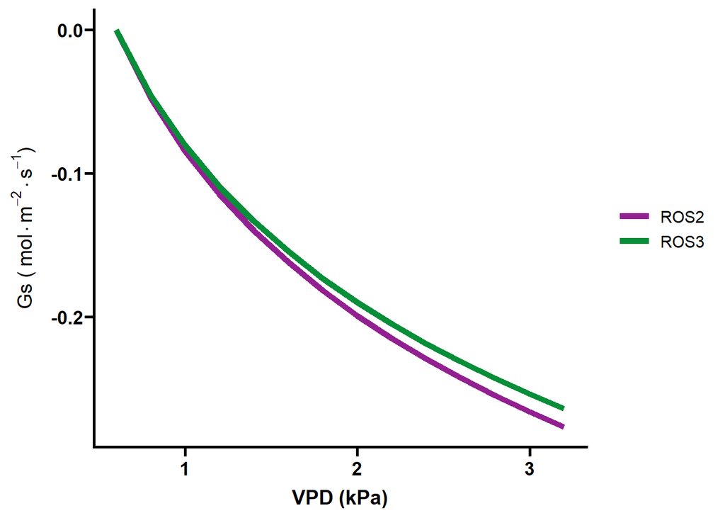

```r
ros3_dd %>%
    ggplot() +

    geom_line(aes(x = ros2_dd$vpd,
                  y= -0.165404 * log(ros2_dd$vpd) + 0.422404-0.5068966,
                  color = "ROS2"),
              size = 2)+
    geom_line(aes(x = ros3_dd$vpd,
                  y= -0.157740  * log(ros3_dd$vpd) + 0.380785-0.4613626,
                  color = "ROS3"),
              size = 2)+
    #ggtitle("Instinct  VPD sensitivity at ROS2 & ROS3")+
    xlab("VPD (kPa)")+
    ylab(TeX("Gs ( $mol \\cdot m^{-2} \\cdot s^{-1}$)"))+
    theme_prism()+
    scale_colour_manual(
        values = c("#922091", "#068E38")
    )
```

From the above figure, it clearly shows that ROS2 is more sensitive to VPD than ROS3 site.

## 3 Gc comparisons between sites for whole summer period

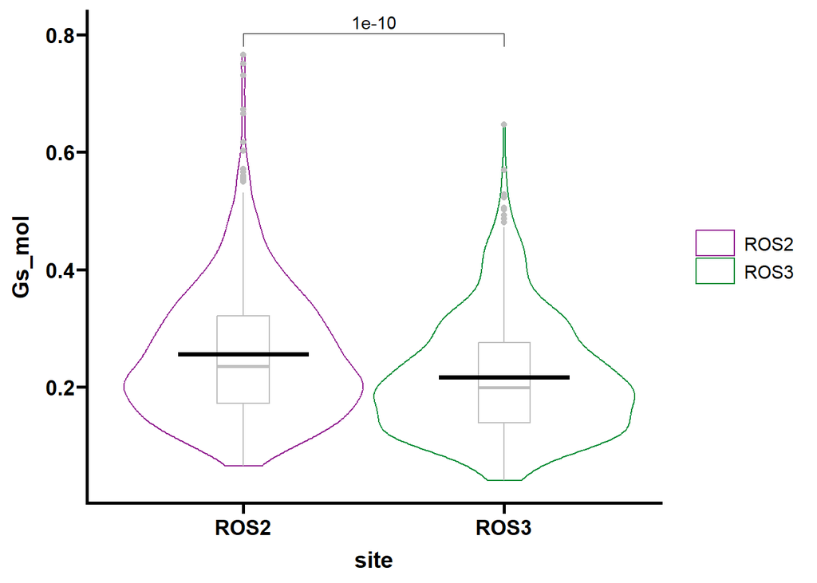

```r
# merge 2 sites
ros2 %>%
    filter(Gs_mol < 1 & Gs_mol>=0) %>%
    group_by(date(dt)) %>%
    transmute(Gs_mol = mean(Gs_mol),
              VPD_f = mean(VPD_f),
              PPFD_f = mean(PPFD_f),
              year = year(dt),
              month = month(dt),
              day = day(dt)) %>%
    unique.data.frame() -> ros2_dd

ros2_dd %>%
    filter(month %in% c(6,7,8)  & PPFD_f > 200) -> ros2_dd

ros3 %>%
    filter((Gs_mol < 1 & Gs_mol >=0 )) %>%
    group_by(date(dt)) %>%
    transmute(Gs_mol = mean(Gs_mol),
              VPD_f = mean(VPD_f),
              PPFD_f = mean(PPFD_f),
              year = year(dt),
              month = month(dt),
              day = day(dt)) %>%
    unique.data.frame() -> ros3_dd

ros3_dd %>%
    filter(month %in% c(6,7,8) & PPFD_f > 200) -> ros3_dd

ros2_dd$site <- "ROS2"
ros3_dd$site <- "ROS3"


df_phy <- rbind(ros2_dd,ros3_dd)

### GGPUBR VERSION ######
my_comparisons <- list( c("ROS2", "ROS3"))

#svg("gs_comparission.svg",width = 5,height = 5)
ggviolin(df_phy,
         x = "site",
         y = "Gs_mol",
         trim = T,
         color = "site",
         palette =c("#922091", "#068E38"),
               add = "boxplot", add.params = list(color = "grey"))+
    stat_compare_means(comparisons = my_comparisons)+
    stat_summary(fun = "mean",
                 geom = "crossbar",
                 width = 0.5,
                 colour = "black")+
    theme_prism()
```

```r
#dev.off()
```

It is also interesting to check how is the difference of Gs during historical dry days we could first add a new column `date` in case we would merge with precipitation anomaly data set.

```r
# add a new column `date`
df_phy %>%
    mutate(Date = make_date(year,month,day)) -> df_phy

glimpse(df_phy)
```

```
Rows: 1,276
Columns: 9
Groups: date(dt) [670]
$ `date(dt)` <date> 2006-06-01, 2006-06-02, 2006-06-03, 2006-06-04, 2006-06-05…
$ Gs_mol     <dbl> 0.2821402, 0.1930718, 0.3669379, 0.5306337, 0.4196468, 0.30…
$ VPD_f      <dbl> 0.7004400, 0.7249812, 0.5159143, 0.2642545, 0.3660416, 0.57…
$ PPFD_f     <dbl> 673.7220, 764.6050, 535.6972, 698.5952, 462.9300, 379.1787,…
$ year       <dbl> 2006, 2006, 2006, 2006, 2006, 2006, 2006, 2006, 2006, 2006,…
$ month      <dbl> 6, 6, 6, 6, 6, 6, 6, 6, 6, 6, 6, 6, 6, 6, 6, 6, 6, 6, 6, 6,…
$ day        <int> 1, 2, 3, 4, 5, 6, 7, 8, 9, 10, 11, 12, 13, 14, 15, 16, 17, …
$ site       <chr> "ROS2", "ROS2", "ROS2", "ROS2", "ROS2", "ROS2", "ROS2", "RO…
$ Date       <date> 2006-06-01, 2006-06-02, 2006-06-03, 2006-06-04, 2006-06-05…
```

## 4 Drought vs GPP capacity

### 4.1 Select dry days based on precipitations

`df_dry` is a data frame with precipitation anomaly records. We defined that if $P_{anomaly}$ < 0 then the day is dry day.

```r
df_dry <- read.csv("merge_ros2_ros3.csv")
df_dry$Date <- ymd(df_dry$Date)
glimpse(df_dry)
```

```
Rows: 1,406
Columns: 20
$ X             <int> 0, 1, 2, 3, 4, 5, 6, 7, 8, 9, 10, 11, 12, 13, 14, 15, 16…
$ index         <dbl> 90, 91, 92, 93, 94, 95, 96, 97, 98, 99, 100, 101, 102, 1…
$ date          <chr> "2006-06-01", "2006-06-02", "2006-06-03", "2006-06-04", …
$ VPD           <dbl> 5.830483, 5.379058, 4.252639, 1.575715, 3.105789, 5.1923…
$ sites         <chr> "ROS2", "ROS2", "ROS2", "ROS2", "ROS2", "ROS2", "ROS2", …
$ DT            <chr> "2006-06-01", "2006-06-02", "2006-06-03", "2006-06-04", …
$ GPP_2000      <dbl> 12.35139, 12.30877, 12.81286, 13.48140, 12.41120, 12.436…
$ R2            <dbl> 0.7100866, 0.7134103, 0.8184913, 0.8384430, 0.8272881, 0…
$ Precipitation <dbl> 0.0, 3.2, 0.0, 3.7, 0.2, 0.0, 0.0, 0.0, 0.0, 0.0, 0.0, 0…
$ Date          <date> 2006-06-01, 2006-06-02, 2006-06-03, 2006-06-04, 2006-06…
$ pet           <dbl> 6.118374e-05, 6.810539e-05, 4.942255e-05, 4.132733e-05, …
$ pet_d         <dbl> 5.286275, 5.884306, 4.270108, 3.570681, 3.068679, 2.6917…
$ Tair          <dbl> 10.807700, 10.971705, 10.193988, 7.668159, 8.410167, 9.2…
$ WAI           <dbl> 51.87326, 49.27959, 49.85562, 47.36283, 48.50969, 46.274…
$ doy           <dbl> 152, 153, 154, 155, 156, 157, 158, 159, 160, 161, 162, 1…
$ μ             <dbl> 1.7933333, 1.4766667, 2.7300000, 2.2033333, 2.1200000, 1…
$ σ             <dbl> 3.937436, 3.204058, 4.625503, 4.136089, 3.666380, 3.5847…
$ zs_rain       <dbl> -0.45545714, 0.53785959, -0.59020611, 0.36185556, -0.523…
$ month         <dbl> 6, 6, 6, 6, 6, 6, 6, 6, 6, 6, 6, 6, 6, 6, 6, 6, 6, 6, 6,…
$ year          <dbl> 2006, 2006, 2006, 2006, 2006, 2006, 2006, 2006, 2006, 20…
```

Now we can select the dry days with `zs_rain` column < 0.

```r
# df_dry1 is the data historical precipitation anomaly  < 0
df_dry %>%
    filter(zs_rain < 0) -> df_dry1
```

we then try to merge the dry dates with physiological parameters

```r
# drought_phy is a data frame which combined `zs_rain` and gpp capacity and other variables
drought_phy <- merge(df_dry1,df_phy,by.x = c("sites","Date"),
      by.y = c("site","Date"))

glimpse(drought_phy)
```

```
Rows: 1,048
Columns: 27
$ sites         <chr> "ROS2", "ROS2", "ROS2", "ROS2", "ROS2", "ROS2", "ROS2", …
$ Date          <date> 2006-06-01, 2006-06-03, 2006-06-05, 2006-06-06, 2006-06…
$ X             <int> 0, 2, 4, 5, 6, 7, 8, 9, 10, 11, 12, 13, 14, 15, 16, 17, …
$ index         <dbl> 90, 92, 94, 95, 96, 97, 98, 99, 100, 101, 102, 103, 104,…
$ date          <chr> "2006-06-01", "2006-06-03", "2006-06-05", "2006-06-06", …
$ VPD           <dbl> 5.830483, 4.252639, 3.105789, 5.192341, 5.472683, 7.3565…
$ DT            <chr> "2006-06-01", "2006-06-03", "2006-06-05", "2006-06-06", …
$ GPP_2000      <dbl> 12.35139, 12.81286, 12.41120, 12.43670, 11.67770, 11.746…
$ R2            <dbl> 0.7100866, 0.8184913, 0.8272881, 0.8233317, 0.8290202, 0…
$ Precipitation <dbl> 0.0, 0.0, 0.2, 0.0, 0.0, 0.0, 0.0, 0.0, 0.0, 0.0, 0.0, 0…
$ pet           <dbl> 6.118374e-05, 4.942255e-05, 3.551712e-05, 3.115488e-05, …
$ pet_d         <dbl> 5.286275, 4.270108, 3.068679, 2.691782, 4.485466, 5.9052…
$ Tair          <dbl> 10.807700, 10.193988, 8.410167, 9.213452, 10.661295, 13.…
$ WAI           <dbl> 51.87326, 49.85562, 48.50969, 46.27421, 43.96050, 41.762…
$ doy           <dbl> 152, 154, 156, 157, 158, 159, 160, 161, 162, 163, 164, 1…
$ μ             <dbl> 1.7933333, 2.7300000, 2.1200000, 1.5766667, 0.8800000, 1…
$ σ             <dbl> 3.937436, 4.625503, 3.666380, 3.584707, 2.696537, 2.9827…
$ zs_rain       <dbl> -0.45545714, -0.59020611, -0.52367726, -0.43983135, -0.3…
$ month.x       <dbl> 6, 6, 6, 6, 6, 6, 6, 6, 6, 6, 6, 6, 6, 6, 6, 6, 6, 6, 6,…
$ year.x        <dbl> 2006, 2006, 2006, 2006, 2006, 2006, 2006, 2006, 2006, 20…
$ `date(dt)`    <date> 2006-06-01, 2006-06-03, 2006-06-05, 2006-06-06, 2006-06…
$ Gs_mol        <dbl> 0.2821402, 0.3669379, 0.4196468, 0.3029466, 0.1992661, 0…
$ VPD_f         <dbl> 0.7004400, 0.5159143, 0.3660416, 0.5734247, 0.6173279, 0…
$ PPFD_f        <dbl> 673.7220, 535.6972, 462.9300, 379.1787, 569.9272, 589.13…
$ year.y        <dbl> 2006, 2006, 2006, 2006, 2006, 2006, 2006, 2006, 2006, 20…
$ month.y       <dbl> 6, 6, 6, 6, 6, 6, 6, 6, 6, 6, 6, 6, 6, 6, 6, 6, 6, 6, 6,…
$ day           <int> 1, 3, 5, 6, 7, 8, 9, 10, 11, 12, 13, 14, 15, 16, 17, 18,…
```

### 4.2 Gs comparisons during dry days

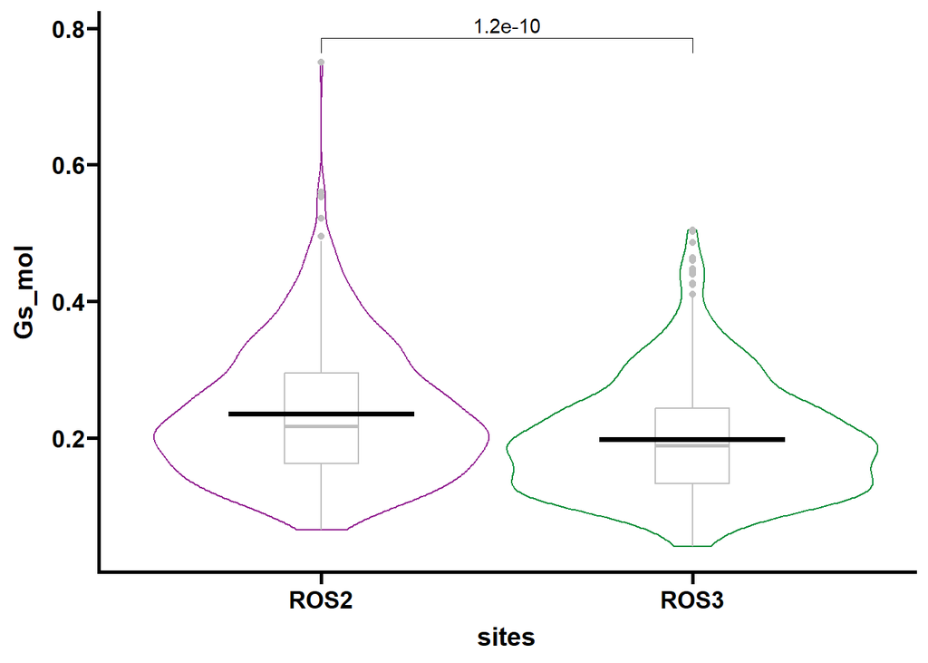

```r
ggviolin(drought_phy,
         x = "sites",
         y = "Gs_mol",
         trim = T,
         color = "sites",
         palette =c("#922091", "#068E38"),
               add = "boxplot", add.params = list(color = "grey"))+
    stat_compare_means(comparisons = my_comparisons)+
    stat_summary(fun = "mean",
                 geom = "crossbar",
                 width = 0.5,
                 colour = "black")+
    theme_prism()+
    theme(legend.position = "none")
```

So, either in summer days or in historical dry days, Gs in ROS2 is significant higher than in ROS3.

### 4.3 Gs sensitivity to VPD during dry days

```r
# first we split 2 sites
# ros2
drought_phy %>%
    filter(sites == "ROS2") -> ros2_drought_phy
# ros3
drought_phy %>%
    filter(sites == "ROS3") -> ros3_drought_phy
```

```r
# creat bin group for vpd and Gs
bins_group <- findInterval(ros2_drought_phy$VPD/10 , seq(from=0.6,to = 3.0,by = 0.2))
ros2_drought_phy$id <- bins_group

Gc2_dry_std <- sd(ros2_drought_phy$Gs_mol)
```

```r
#taking different stratages
## get mean value
ros2_drought_phy%>%
    group_by(id) %>%
    transmute(Gs_mol = mean(Gs_mol)+Gc2_dry_std) %>%
    unique.data.frame() -> ros2_drought_phy_dd

ros2_drought_phy_dd$vpd <- seq(from=0.6,to = 3.2,by = 0.2)
```

The above code blocks are wrong, since the equation needs HH time resolution, here DD was used, so …

```r
ros2$date <- date(ros2$dt)
```

Let’s split the `df_dry1` again into *ROS2* and *ROS3*.

```r
df_dry1 %>%
    filter(sites == "ROS2") -> ros2_drought_phy
```

Then, lets merge again to combine all HH data in dry days. We get the HH vpd and Gs during drought days.

```r
ros2_drought_phy_hh <- merge(ros2,ros2_drought_phy,by= "date")
```

```r
# impossible with GS > 1
ros2_drought_phy_hh %>%
    filter(Gs_mol < 1 & Gs_mol >=0) -> ros2_drought_phy_hh
```

Next, we create VPD bins.

```r
# creat bin group for vpd and Gs
bins_group <- findInterval(ros2_drought_phy_hh$VPD_f,
                           seq(from=0.6,to = 3.0,by = 0.2))
ros2_drought_phy_hh$id <- bins_group

Gc2_std_hh <- sd(ros2_drought_phy_hh$Gs_mol)

#taking different stratages
## get mean value
ros2_drought_phy_hh %>%
    group_by(id) %>%
    transmute(Gs_mol = mean(Gs_mol)+ Gc2_std_hh) %>%
    unique.data.frame() -> ros2_drought_phy_dd

ros2_drought_phy_dd$vpd <- seq(from=0.6,to = 3.2,by = 0.2)
```

We then, simulate the Gs VPD formula again

```r
# simulate the GS sensitivity
mod_dry_ros2 <- nlsLM(Gs_mol ~ -m * log(vpd) + b,
             data = ros2_drought_phy_dd,
             start=list(m=10,b=2),
             algorithm = "plinear",
             # alg = "plinear",
             na.action = na.omit)
summary(mod_dry_ros2)
```

```
Formula: Gs_mol ~ -m * log(vpd) + b

Parameters:
  Estimate Std. Error t value Pr(>|t|)
m 0.119160   0.010563   11.28 9.59e-08 ***
b 0.382074   0.007692   49.67 2.91e-15 ***
---
Signif. codes:  0 '***' 0.001 '**' 0.01 '*' 0.05 '.' 0.1 ' ' 1

Residual standard error: 0.01966 on 12 degrees of freedom

Number of iterations to convergence: 2
Achieved convergence tolerance: 1.49e-08
```

Now, let’s move to ROS3 site, which is regarded as *Control*, we put all similar code together…

```r
ros3$date <- date(ros3$dt)
df_dry1 %>% filter(sites == "ROS3") -> ros3_drought_phy
ros3_drought_phy_hh <- merge(ros3,ros3_drought_phy,by= "date")
ros3_drought_phy_hh %>%
    filter(Gs_mol < 1 & Gs_mol >=0) -> ros3_drought_phy_hh
# create bin group for VPD and Gs
bins_group <- findInterval(ros3_drought_phy_hh$VPD_f,
                           seq(from=0.6,to = 3.0,by = 0.2))
ros3_drought_phy_hh$id <- bins_group

Gc3_std_hh <- sd(ros3_drought_phy_hh$Gs_mol)

#taking different stratages
## get mean value
ros3_drought_phy_hh %>%
    group_by(id) %>%
    transmute(Gs_mol = mean(Gs_mol)+ Gc3_std_hh) %>%
    unique.data.frame() -> ros3_drought_phy_dd

ros3_drought_phy_dd$vpd <- seq(from=0.6,to = 3.2,by = 0.2)
```

```r
# simulate the GS sensitivity at ROS3 site
mod_dry_ros3 <- nlsLM(Gs_mol ~ -m * log(vpd) + b,
             data = ros3_drought_phy_dd,
             start=list(m=10,b=2),
             algorithm = "plinear",
             na.action = na.omit)
summary(mod_dry_ros3)
```

```
Formula: Gs_mol ~ -m * log(vpd) + b

Parameters:
  Estimate Std. Error t value Pr(>|t|)
m 0.107228   0.012629   8.491 2.03e-06 ***
b 0.332753   0.009197  36.180 1.27e-13 ***
---
Signif. codes:  0 '***' 0.001 '**' 0.01 '*' 0.05 '.' 0.1 ' ' 1

Residual standard error: 0.02351 on 12 degrees of freedom

Number of iterations to convergence: 2
Achieved convergence tolerance: 1.49e-08
```

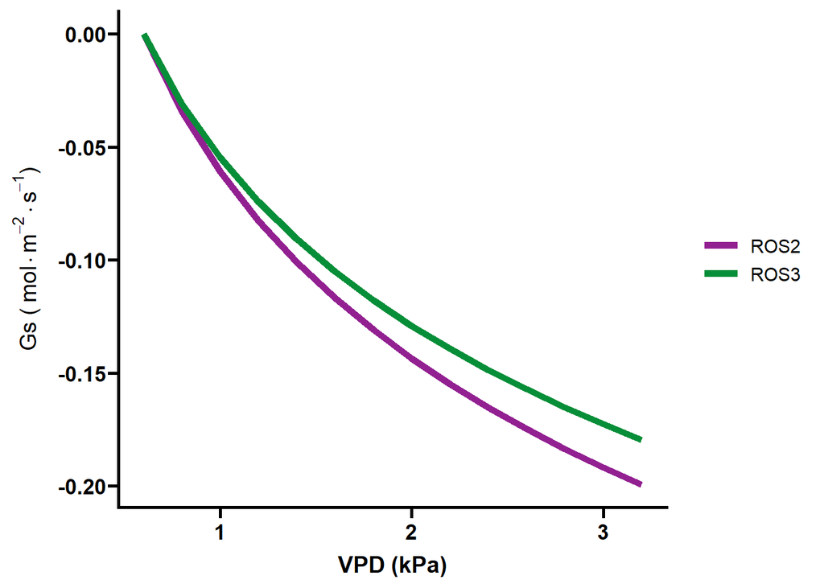

```r
ros2_drought_phy_dd %>%
    ggplot() +
    geom_line(aes(x = ros2_drought_phy_dd$vpd,
                  y= -0.119160  * log(ros2_drought_phy_dd$vpd) + 0.382074-0.4429440,
                  color = "ROS2"),
              size = 2)+
   geom_line(aes(x = ros3_drought_phy_dd$vpd,
                  y= -0.107228  * log(ros3_drought_phy_dd$vpd) + 0.332753-0.3875278,
                  color = "ROS3"),
              size = 2)+
    # ggtitle("Instinct  VPD sensitivity at ROS2 & ROS3")+
    xlab("VPD (kPa)")+
    ylab(TeX("Gs ( $mol \\cdot m^{-2} \\cdot s^{-1}$)"))+
    theme_prism()+
   # theme(legend.position = "none")+
    scale_colour_manual(
        values = c("#922091", "#068E38")
    )
```

The above figure also showed that, even during dry days, ROS2 has more sensitive Gs to VPD when compared to ROS3 site.

## 5 Last part–Which variable regulate the N addition induced GPP capacity difference

Firstly, dry days should be selected separately from ROS2 and ROS3 site. Based on the observation length from ROS2 and ROS3 site, what we should to do set ROS2 date as a baseline date. And the data set `drought_phy` already be combined all drought records.

```r
drought_phy %>%
    filter(sites == "ROS2") %>%
    select(Date,GPP_2000,VPD_f,Gs_mol,WAI,Tair) -> ROS2_dry_days

drought_phy %>%
    filter(sites == "ROS3") %>%
    select(Date,GPP_2000,VPD_f,Gs_mol,WAI,Tair) -> ROS3_dry_days
```

```r
base_date <- data.frame(Date = ROS2_dry_days$Date)
ROS3_dry_days <- merge(base_date,ROS3_dry_days,by = "Date",all.x = T)
glimpse(ROS3_dry_days)
```

```
Rows: 548
Columns: 6
$ Date     <date> 2006-06-01, 2006-06-03, 2006-06-05, 2006-06-06, 2006-06-07, …
$ GPP_2000 <dbl> 13.068583, 13.738732, 12.979130, 12.696418, 11.316021, 10.875…
$ VPD_f    <dbl> 0.5970332, 0.5529197, 0.3866638, 0.5585495, 0.6914902, 0.8176…
$ Gs_mol   <dbl> 0.2926552, 0.3851740, 0.4444386, 0.2905051, 0.2030080, 0.1780…
$ WAI      <dbl> 60.63792, 57.76572, 55.64856, 53.24578, 50.96556, 48.41728, 4…
$ Tair     <dbl> 9.800823, 9.518677, 7.998198, 8.295844, 10.390573, 12.977146,…
```

Now we have the dry data at the 2 sites with exactly same date.

```r
Delta_D <- data.frame(d_gpp = ROS2_dry_days$GPP_2000 - ROS3_dry_days$GPP_2000,
                    d_gs = ROS2_dry_days$Gs_mol - ROS3_dry_days$Gs_mol,
                    d_tair = (ROS2_dry_days$Tair + ROS3_dry_days$Tair)/2,
                    d_wai = ROS2_dry_days$WAI - ROS3_dry_days$WAI,
                    d_vpd = (ROS2_dry_days$VPD_f + ROS3_dry_days$VPD_f) /2)
```

We applied a random forest model to rank the importance of variables to the N addition induced difference between ROS2 and ROS3

```r
library(ranger)
rf_fit <-  ranger(d_gpp~d_gs+d_wai+d_tair+d_vpd,
                  data = na.omit(Delta_D),
                        min.node.size = 5,
                  num.trees = 1500,
                  quantreg = F,
                  importance = "permutation")
#importance(rf_fit)
#caret::varImp(rf_fit,scale = T)
imps <- importance_pvalues(rf_fit,
                           method = "altmann",
                   formula = d_gpp~d_gs+d_wai+d_tair+d_vpd,
                   data = na.omit(Delta_D))
```

We then plot the difference

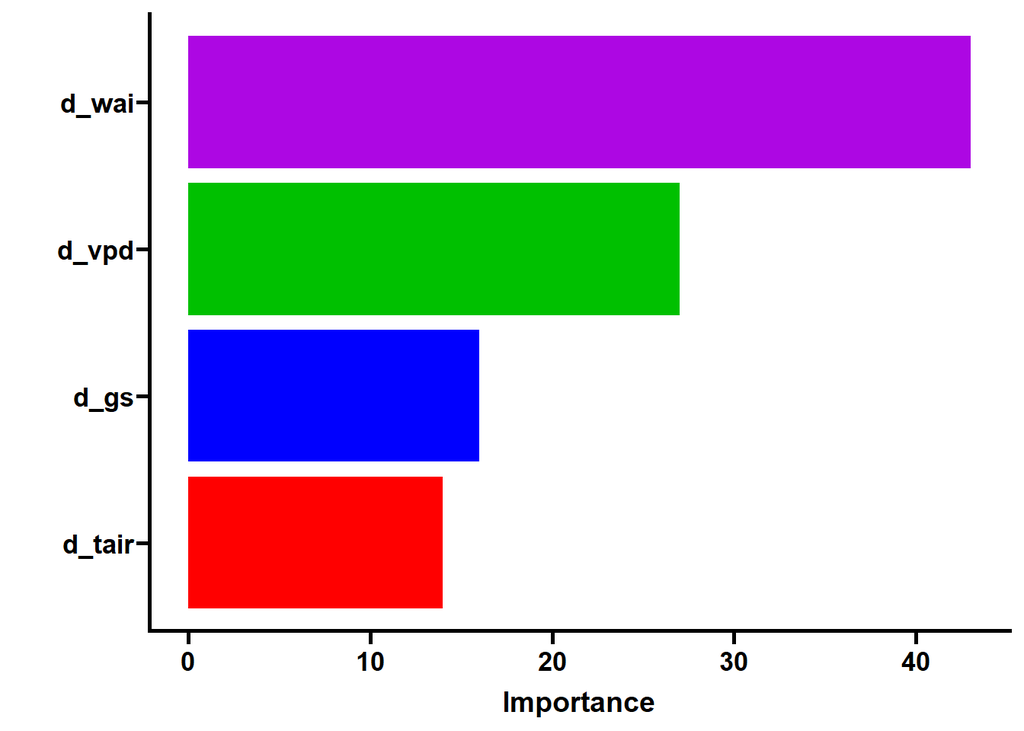

```r
imps <- as.data.frame(imps)
imps$variable <- row.names(imps)

#plot
positions <- rev(c("d_wai", "d_vpd", "d_gs","d_tair"))
#svg("var_importance.svg",width = 5,height = 5)
imps %>%
    mutate(percen = round(importance/ sum(importance) * 100)) %>%
    ggplot(aes(variable,percen,fill = variable))+
    geom_col()+
    scale_fill_prism()+
    theme_prism()+
    coord_flip()+
    scale_x_discrete(limits = positions)+
    xlab(" ")+
    ylab("Importance")+
    theme(legend.position = "none")
```

```r
#dev.off()
```

We also illustrated the positive or negative effects of those variables by using

partial dependence plots.

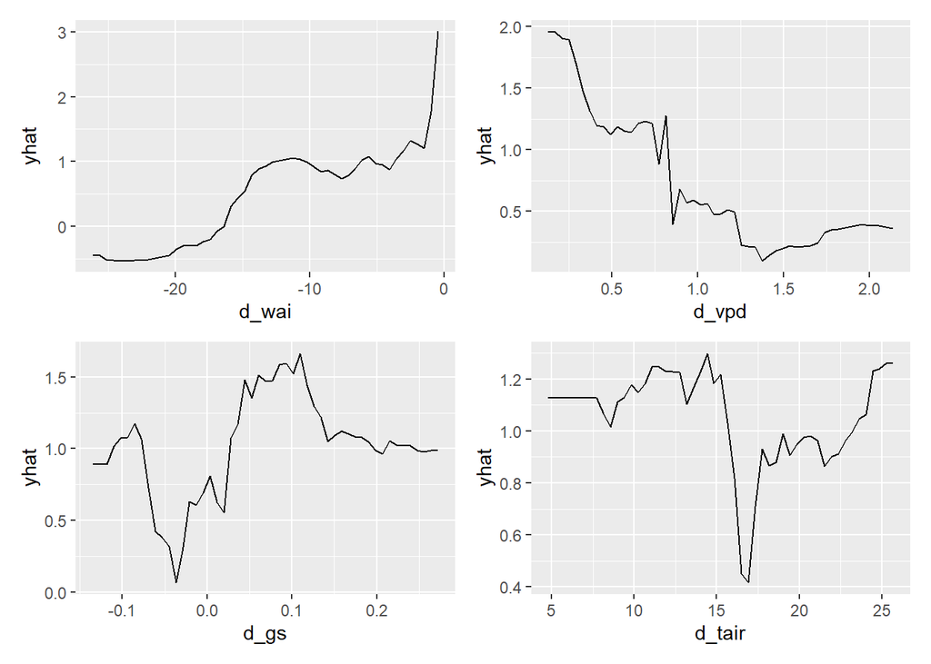

```r
library(pdp)
library(patchwork)
# tair
par.tair <- partial(rf_fit, pred.var = c("d_tair"), chull = TRUE)
plot.tair <- autoplot(par.tair, contour = TRUE)
# gs
par.gs <- partial(rf_fit, pred.var = c("d_gs"), chull = TRUE)
plot.gs <- autoplot(par.gs, contour = TRUE)
# vpd
par.vpd <- partial(rf_fit, pred.var = c("d_vpd"), chull = TRUE)
plot.vpd <- autoplot(par.vpd, contour = TRUE)
# wai
par.wai <- partial(rf_fit, pred.var = c("d_wai"), chull = TRUE)
plot.wai <- autoplot(par.wai, contour = TRUE)

(plot.wai + plot.vpd) / (plot.gs + plot.tair)
```

So, based on the above figure, we could say:

- Drought is the most significant factor for limiting the photosynthesis between N and control group. In other words, benefits from N addition will be trade-off by drought, especially the soil drought rather the atmospheric drought.
- The physiological factor —- surface conductance also plays an important role in regulating the difference of GPP capacity between N and control group. And $Gs$ in N addition site (ROS2) is more sensitive to VDP.
- Moreover, our study also illustrated that, the temperature is not necessary a factor to limit the photosynthesis. Probably, the most optimal temperature for photosynthesis is still higher than the current air temperature.